# NYPD Shooting Incident

Yee

2026-03-19

# Objective

The main objectives of this report is to analyze: How do shooting incidents vary over time, across boroughs, and by time of day, and are borough and hour associated with whether an incident is statistically flagged as a murder?

This question is important because it allows the analysis to examine both descriptive patterns in the data and a simple modelling question about murder classification.

## 1. Setup environment

This chunk loads the packages used in the analysis. The tidyverse package is used for importing, cleaning, transforming, and visualizing the data. The lubridate package is used for working with dates.

```r
knitr::opts_chunk$set(echo = TRUE)

library(tidyverse)
library(lubridate)
```

## 2. Import data and preview

The data used in this report comes from NYC Open Data, specifically the NYPD Shooting Incident Data (Historic) dataset. It was accessed from the following source:

https://catalog.data.gov/dataset/nypd-shooting-incident-data-historic/resource/c564b578-fd8a-4005-8365-34150d306cc

The dataset contains historical records of shooting incidents in New York City. It includes variables such as the date and time of the incident, borough, precinct, location information, whether the incident was statistically flagged as a murder, and demographic characteristics of victims and perpetrators when available. This dataset is useful for studying patterns in shootings across time, place, and demographic groups, although some variables contain missing values.

This chunk imports the NYPD shooting incident data directly from the online source. This makes the analysis reproducible because anyone running the code can access the same dataset. The glimpse() function provides an overview of the variables and structure of the data.

```r
url <- "https://data.cityofnewyork.us/api/views/833y-fsy8/rows.csv?accessType=DOWNLOAD"

shootings_raw <- read_csv(url, show_col_types = FALSE)

glimpse(shootings_raw)
```

```
## Rows: 29,744
## Columns: 21
## $ INCIDENT_KEY            <dbl> 231974218, 177934247, 255028563, 25384540, 726…
## $ OCCUR_DATE              <chr> "08/09/2021", "04/07/2018", "12/02/2022", "11/…
## $ OCCUR_TIME              <time> 01:06:00, 19:48:00, 22:57:00, 01:50:00, 01:58…
## $ BORO                    <chr> "BRONX", "BROOKLYN", "BRONX", "BROOKLYN", "BRO…
## $ LOC_OF_OCCUR_DESC       <chr> NA, NA, "OUTSIDE", NA, NA, NA, NA, NA, NA, NA,…
## $ PRECINCT                <dbl> 40, 79, 47, 66, 46, 42, 71, 69, 75, 69, 40, 42…
## $ JURISDICTION_CODE       <dbl> 0, 0, 0, 0, 0, 2, 0, 2, 0, 0, 0, 2, 0, 0, 2, 0…
## $ LOC_CLASSFCTN_DESC      <chr> NA, NA, "STREET", NA, NA, NA, NA, NA, NA, NA, …
## $ LOCATION_DESC           <chr> NA, NA, "GROCERY/BODEGA", "PVT HOUSE", "MULTI …
## $ STATISTICAL_MURDER_FLAG <lgl> FALSE, TRUE, FALSE, TRUE, TRUE, FALSE, TRUE, F…
## $ PERP_AGE_GROUP          <chr> NA, "25-44", "(null)", "UNKNOWN", "25-44", "18…
## $ PERP_SEX                <chr> NA, "M", "(null)", "U", "M", "M", NA, NA, "M",…
## $ PERP_RACE               <chr> NA, "WHITE HISPANIC", "(null)", "UNKNOWN", "BL…
## $ VIC_AGE_GROUP           <chr> "18-24", "25-44", "25-44", "18-24", "<18", "18…
## $ VIC_SEX                 <chr> "M", "M", "M", "M", "F", "M", "M", "M", "M", "…
## $ VIC_RACE                <chr> "BLACK", "BLACK", "BLACK", "BLACK", "BLACK", "…
## $ X_COORD_CD              <dbl> 1006343.0, 1000082.9, 1020691.0, 985107.3, 100…
## $ Y_COORD_CD              <dbl> 234270.0, 189064.7, 257125.0, 173349.8, 247502…
## $ Latitude                <dbl> 40.80967, 40.68561, 40.87235, 40.64249, 40.845…
## $ Longitude               <dbl> -73.92019, -73.94291, -73.86823, -73.99691, -7…
## $ Lon_Lat                 <chr> "POINT (-73.92019278899994 40.80967347200004)"…
```

## 3. Clean, tidy data, and pre-process dates

This chunk standardizes variable names, parses dates, and handles missing values. It also converts the date and time into proper formats. It creates new variables for year, month, weekday, and hour. These variables make it easier to analyze trends over time and patterns by time of day.

```r
shootings <- shootings_raw %>%
  rename(
    date = OCCUR_DATE,
    time = OCCUR_TIME,
    borough = BORO,
    precinct = PRECINCT,
    murder_flag = STATISTICAL_MURDER_FLAG,
    vic_age_group = VIC_AGE_GROUP,
    vic_sex = VIC_SEX,
    vic_race = VIC_RACE,
    perp_age_group = PERP_AGE_GROUP,
    perp_sex = PERP_SEX,
    perp_race = PERP_RACE
  ) %>%
  mutate(
    date = mdy(date),
    year = year(date),
    month = month(date, label = TRUE, abbr = TRUE),
    weekday = wday(date, label = TRUE, abbr = TRUE),
    hour = as.numeric(substr(time, 1, 2)),
    borough = str_to_title(borough)
  )

glimpse(shootings)
```

```
## Rows: 29,744
## Columns: 25
## $ INCIDENT_KEY       <dbl> 231974218, 177934247, 255028563, 25384540, 72616285…
## $ date               <date> 2021-08-09, 2018-04-07, 2022-12-02, 2006-11-19, 20…
## $ time               <time> 01:06:00, 19:48:00, 22:57:00, 01:50:00, 01:58:00, …
## $ borough            <chr> "Bronx", "Brooklyn", "Bronx", "Brooklyn", "Bronx", …
## $ LOC_OF_OCCUR_DESC  <chr> NA, NA, "OUTSIDE", NA, NA, NA, NA, NA, NA, NA, NA, …
## $ precinct           <dbl> 40, 79, 47, 66, 46, 42, 71, 69, 75, 69, 40, 42, 71,…
## $ JURISDICTION_CODE  <dbl> 0, 0, 0, 0, 0, 2, 0, 2, 0, 0, 0, 2, 0, 0, 2, 0, 0, …
## $ LOC_CLASSFCTN_DESC <chr> NA, NA, "STREET", NA, NA, NA, NA, NA, NA, NA, NA, N…
## $ LOCATION_DESC      <chr> NA, NA, "GROCERY/BODEGA", "PVT HOUSE", "MULTI DWELL…
## $ murder_flag        <lgl> FALSE, TRUE, FALSE, TRUE, TRUE, FALSE, TRUE, FALSE,…
## $ perp_age_group     <chr> NA, "25-44", "(null)", "UNKNOWN", "25-44", "18-24",…
## $ perp_sex           <chr> NA, "M", "(null)", "U", "M", "M", NA, NA, "M", "M",…
## $ perp_race          <chr> NA, "WHITE HISPANIC", "(null)", "UNKNOWN", "BLACK",…
## $ vic_age_group      <chr> "18-24", "25-44", "25-44", "18-24", "<18", "18-24",…
## $ vic_sex            <chr> "M", "M", "M", "M", "F", "M", "M", "M", "M", "M", "…
## $ vic_race           <chr> "BLACK", "BLACK", "BLACK", "BLACK", "BLACK", "BLACK…
## $ X_COORD_CD         <dbl> 1006343.0, 1000082.9, 1020691.0, 985107.3, 1009853.…
## $ Y_COORD_CD         <dbl> 234270.0, 189064.7, 257125.0, 173349.8, 247502.6, 2…
## $ Latitude           <dbl> 40.80967, 40.68561, 40.87235, 40.64249, 40.84598, 4…
## $ Longitude          <dbl> -73.92019, -73.94291, -73.86823, -73.99691, -73.907…
## $ Lon_Lat            <chr> "POINT (-73.92019278899994 40.80967347200004)", "PO…
## $ year               <dbl> 2021, 2018, 2022, 2006, 2010, 2012, 2011, 2012, 201…
## $ month              <ord> Aug, Apr, Dec, Nov, May, Jul, Jul, Jul, Apr, May, O…
## $ weekday            <ord> Mon, Sat, Fri, Sun, Sun, Sun, Tue, Sat, Tue, Sat, M…
## $ hour               <dbl> 1, 19, 22, 1, 1, 21, 22, 23, 15, 15, 0, 2, 22, 4, 1…
```

## 4. Check missing values

This chunk counts the number of missing values in each variable. The main variables used in this report, such as date, time, borough, murder flag, year, month, weekday, and hour, have no missing values. This is helpful because it means the main visualizations and model can be created without losing observations. However, some perpetrator variables and location description variables have substantial missing data, which is important to keep in mind when interpreting results.

```r
colSums(is.na(shootings))
```

```
##       INCIDENT_KEY               date               time            borough
##                  0                  0                  0                  0
##  LOC_OF_OCCUR_DESC           precinct  JURISDICTION_CODE LOC_CLASSFCTN_DESC
##              25596                  0                  2              25596
##      LOCATION_DESC        murder_flag     perp_age_group           perp_sex
##              14977                  0               9344               9310
##          perp_race      vic_age_group            vic_sex           vic_race
##               9310                  0                  0                  0
##         X_COORD_CD         Y_COORD_CD           Latitude          Longitude
##                  0                  0                 97                 97
##            Lon_Lat               year              month            weekday
##                 97                  0                  0                  0
##               hour
##                  0
```

## 5. Basic summary

This summary gives an overview of the dataset, including the distributions of numeric variables and the categories in character variables. It helps confirm that the data has been imported and transformed correctly before moving into deeper analysis.

```r
summary(shootings)
```

```
##   INCIDENT_KEY            date                 time
##  Min.   :  9953245   Min.   :2006-01-01   Min.   :00:00:00.000000
##  1st Qu.: 67321140   1st Qu.:2009-10-29   1st Qu.:03:30:45.000000
##  Median :109291972   Median :2014-03-25   Median :15:15:00.000000
##  Mean   :133850951   Mean   :2014-10-31   Mean   :12:46:10.874798
##  3rd Qu.:214741917   3rd Qu.:2020-06-29   3rd Qu.:20:44:00.000000
##  Max.   :299462478   Max.   :2024-12-31   Max.   :23:59:00.000000
##
##    borough          LOC_OF_OCCUR_DESC     precinct      JURISDICTION_CODE
##  Length:29744       Length:29744       Min.   :  1.00   Min.   :0.0000
##  Class :character   Class :character   1st Qu.: 44.00   1st Qu.:0.0000
##  Mode  :character   Mode  :character   Median : 67.00   Median :0.0000
##                                        Mean   : 65.23   Mean   :0.3181
##                                        3rd Qu.: 81.00   3rd Qu.:0.0000
##                                        Max.   :123.00   Max.   :2.0000
##                                                         NA's   :2
##  LOC_CLASSFCTN_DESC LOCATION_DESC      murder_flag     perp_age_group
##  Length:29744       Length:29744       Mode :logical   Length:29744
##  Class :character   Class :character   FALSE:23979     Class :character
##  Mode  :character   Mode  :character   TRUE :5765      Mode  :character
##
##
##
##
##    perp_sex          perp_race         vic_age_group        vic_sex
##  Length:29744       Length:29744       Length:29744       Length:29744
##  Class :character   Class :character   Class :character   Class :character
##  Mode  :character   Mode  :character   Mode  :character   Mode  :character
##
##
##
##
##    vic_race           X_COORD_CD        Y_COORD_CD        Latitude
##  Length:29744       Min.   : 914928   Min.   :125757   Min.   :40.51
##  Class :character   1st Qu.:1000094   1st Qu.:183042   1st Qu.:40.67
##  Mode  :character   Median :1007826   Median :195506   Median :40.70
##                     Mean   :1009442   Mean   :208722   Mean   :40.74
##                     3rd Qu.:1016739   3rd Qu.:239980   3rd Qu.:40.83
##                     Max.   :1066815   Max.   :271128   Max.   :40.91
##                                                        NA's   :97
##    Longitude        Lon_Lat               year          month       weekday
##  Min.   :-74.25   Length:29744       Min.   :2006   Jul    : 3513   Sun:5872
##  1st Qu.:-73.94   Class :character   1st Qu.:2009   Aug    : 3352   Mon:4274
##  Median :-73.91   Mode  :character   Median :2014   Jun    : 3091   Tue:3469
##  Mean   :-73.91                      Mean   :2014   Sept   : 2808   Wed:3283
##  3rd Qu.:-73.88                      3rd Qu.:2020   May    : 2795   Thu:3295
##  Max.   :-73.70                      Max.   :2024   Oct    : 2483   Fri:3901
##  NA's   :97                                         (Other):11702   Sat:5650
##       hour
##  Min.   : 0.0
##  1st Qu.: 3.0
##  Median :15.0
##  Mean   :12.3
##  3rd Qu.:20.0
##  Max.   :23.0
##
```

## 6. Number of shooting incidents by year

This graph shows how the number of shooting incidents changes over time. It helps identify whether incidents increased, decreased, or fluctuated across years. This is one of the most important descriptive views in the report because it shows the long-term pattern in the data.

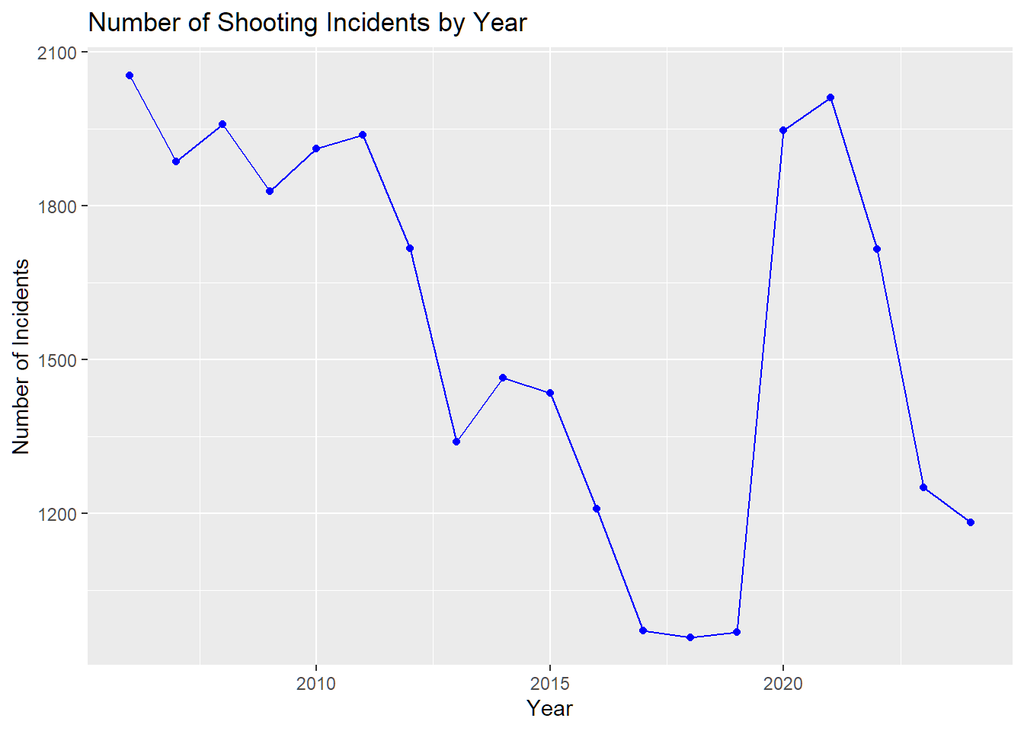

```r
shootings %>%
  count(year) %>%
  ggplot(aes(x = year, y = n)) +
  geom_line(color = "blue") +
  geom_point(color = "blue") +
  labs(
    title = "Number of Shooting Incidents by Year",
    x = "Year",
    y = "Number of Incidents"
  )
```

**Conclusion:** The number of shooting incidents generally declined from the late 2000s to around 2018–2019, followed by a sharp increase in 2020 and 2021. After that spike, incidents decreased again, although they still remained above the lowest levels seen before 2020.

## 7. Number of shootings incidents by borough

This bar chart compares the number of shooting incidents across boroughs. It shows that incidents are not evenly distributed across the city. Some boroughs have much higher counts than others, which suggests that place is an important dimension of the dataset.

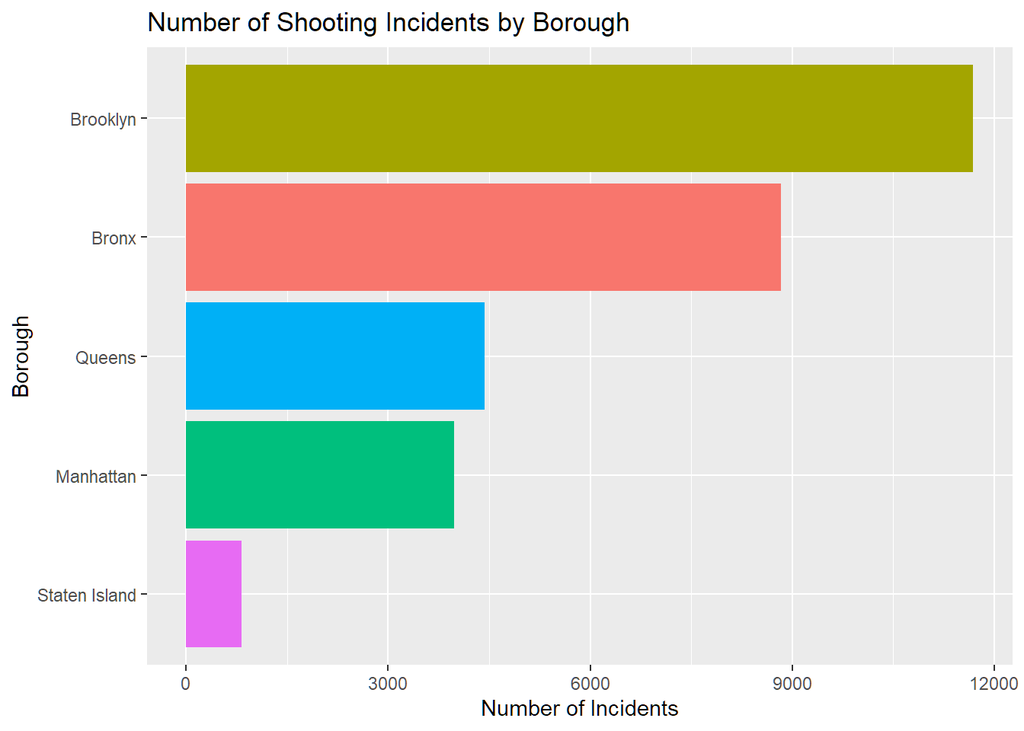

```r
shootings %>%
  count(borough) %>%
  ggplot(aes(x = reorder(borough, n), y = n, fill = borough)) +
  geom_col() +
  coord_flip() +
  labs(
    title = "Number of Shooting Incidents by Borough",
    x = "Borough",
    y = "Number of Incidents"
  ) +
  theme(legend.position = "none")
```

**Conclusion:** Shooting incidents are not evenly distributed across boroughs. Brooklyn has the highest number of recorded incidents, followed by the Bronx, while Staten Island has the lowest.

## 8. Number of shooting incidents by hour of day

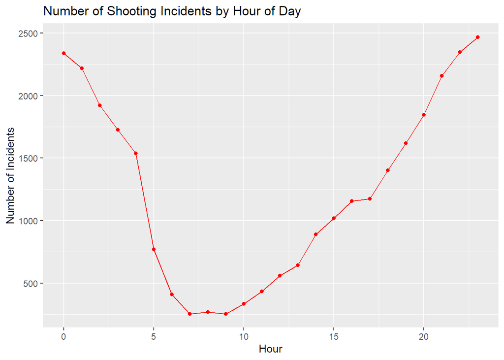

```r
shootings %>%
  count(hour) %>%
  ggplot(aes(x = hour, y = n)) +
  geom_line(color = "red") +
  geom_point(color = "red") +
  labs(
    title = "Number of Shooting Incidents by Hour of Day",
    x = "Hour",
    y = "Number of Incidents"
  )
```

**Conclusion:** Shooting incidents are most common during the late evening and around midnight, while the lowest number of incidents occurs in the early morning hours. This suggests that shootings are more concentrated at night than during the daytime.

## 9. Heatmap of shootings by Weekday and hour

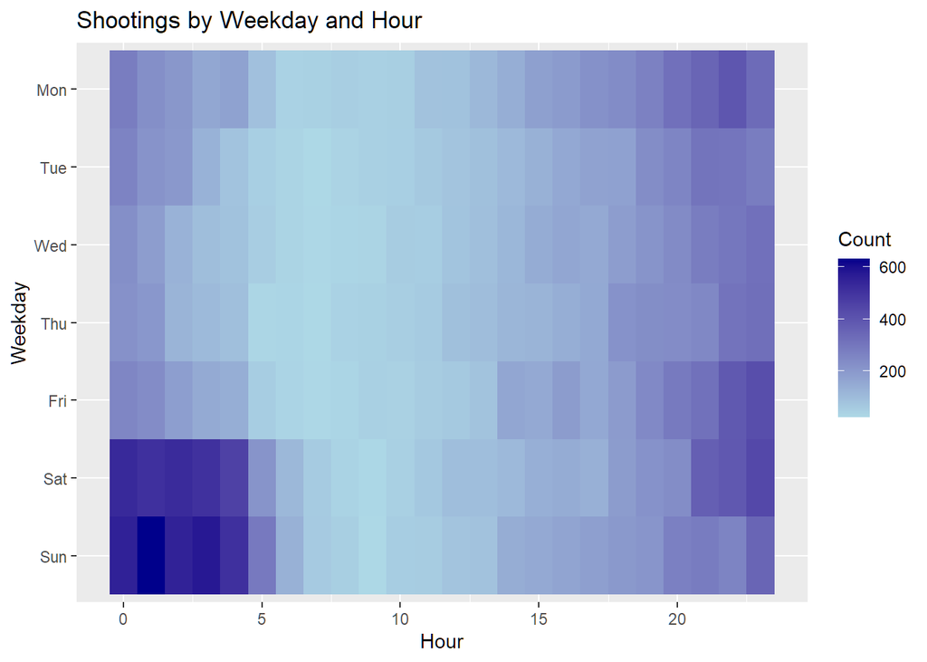

```r
shootings %>%
  mutate(
    weekday = factor(
      weekday,
      levels = c("Mon", "Tue", "Wed", "Thu", "Fri", "Sat", "Sun")
    )
  ) %>%
  count(weekday, hour) %>%
  ggplot(aes(x = hour, y = weekday, fill = n)) +
  geom_tile() +
  scale_fill_gradient(low = "lightblue", high = "darkblue") +
  scale_y_discrete(limits = rev(c("Mon", "Tue", "Wed", "Thu", "Fri", "Sat", "Sun"))) +
  labs(
    title = "Shootings by Weekday and Hour",
    x = "Hour",
    y = "Weekday",
    fill = "Count"
  )
```

**Conclusion:** As seen earlier, shooting incidents are most concentrated during late-night hours. We then plot the occurrence with day of the week and noticed that shooting incidents are occur more on weekends such as Saturday and Sunday. In contrast, incidents are less common during the morning and early daytime hours across most weekdays.

## 10. Logistic Regression Model

This chunk fits a logistic regression model predicting whether an incident was flagged as a murder. The predictors in the model are hour and borough. Since the outcome variable is binary, logistic regression is an appropriate method. This model helps examine whether time of day and borough are associated with the odds of an incident being classified as a murder.

```r
model1 <- glm(murder_flag ~ hour + borough, data = shootings, family = "binomial")

summary(model1)
```

```
##
## Call:
## glm(formula = murder_flag ~ hour + borough, family = "binomial",
##     data = shootings)
##
## Coefficients:
##                        Estimate Std. Error z value Pr(>|z|)
## (Intercept)          -1.4261334  0.0346101 -41.206   <2e-16 ***
## hour                  0.0009705  0.0017430   0.557   0.5777
## boroughBrooklyn      -0.0048807  0.0355666  -0.137   0.8909
## boroughManhattan     -0.0965102  0.0491740  -1.963   0.0497 *
## boroughQueens         0.0086452  0.0464008   0.186   0.8522
## boroughStaten Island  0.0704791  0.0902077   0.781   0.4346
## ---
## Signif. codes:  0 '***' 0.001 '**' 0.01 '*' 0.05 '.' 0.1 ' ' 1
##
## (Dispersion parameter for binomial family taken to be 1)
##
##     Null deviance: 29251  on 29743  degrees of freedom
## Residual deviance: 29245  on 29738  degrees of freedom
## AIC: 29257
##
## Number of Fisher Scoring iterations: 4
```

Among the borough variables, Manhattan was the only statistically significant result, with a coefficient of -0.0965102 and a p-value of 0.0497, suggesting slightly lower odds of murder classification compared with the reference borough.

Brooklyn, Queens, and Staten Island were not statistically significant, with p-values of 0.8909, 0.8522, and 0.4346 respectively. Overall, the model explains only a very small amount of variation, as shown by the null deviance of 29251 and residual deviance of 29245, meaning hour and borough alone do not strongly predict whether an incident is classified as a murder.

## 11. Predicted Probabilities

This chunk calculates predicted probabilities from the logistic regression model. These values estimate the probability that each incident is flagged as a murder based on the variables in the model.

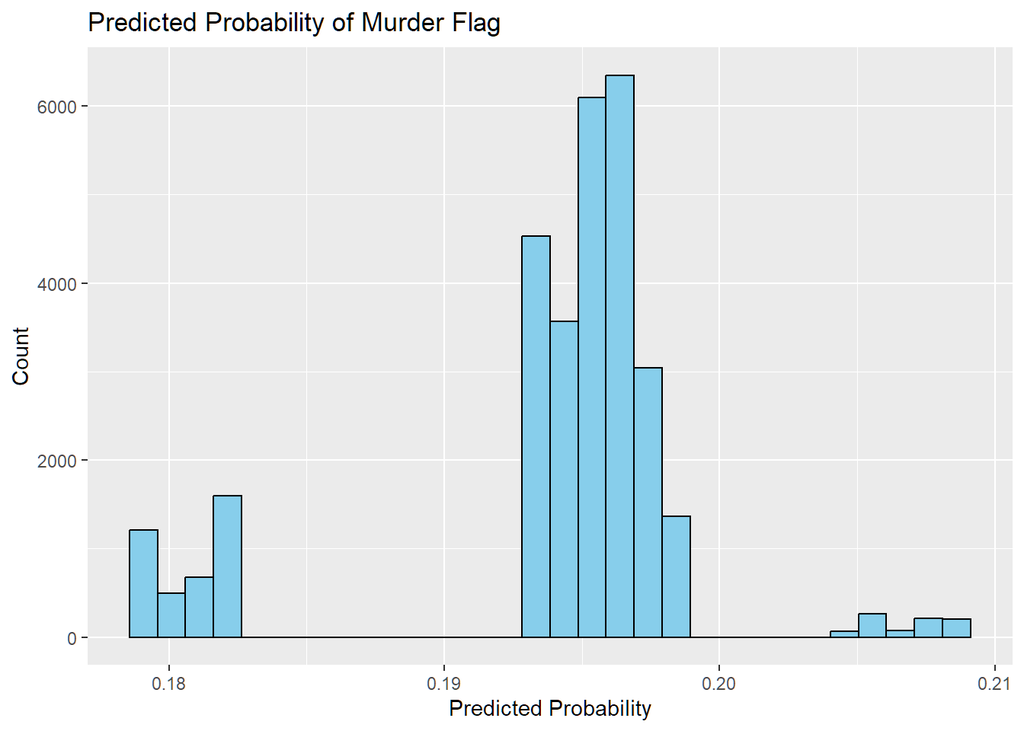

```r
model_data <- shootings %>%
  mutate(predicted_prob = predict(model1, type = "response"))

ggplot(model_data, aes(x = predicted_prob)) +
  geom_histogram(bins = 30, fill = "skyblue", color = "black") +
  labs(
    title = "Predicted Probability of Murder Flag",
    x = "Predicted Probability",
    y = "Count"
  )
```

**Conclusion:** The predicted probabilities are concentrated in a narrow range, mostly around 0.19 to 0.20, which suggests that the model does not strongly separate incidents into very low- or high-risk groups. This supports the earlier result that hour and borough alone have limited power in predicting whether a shooting is flagged as a murder.

This also aligns with the logistic regression results because the predicted probabilities are clustered in a very narrow range, showing that hour and borough do not provide strong predictive power for whether an incident is flagged as a murder.

## 12. Bias and Limitations

This dataset has several possible sources of bias and limitation.

Firstly, it only includes shooting incidents that were recorded by police, so it may not represent all events. Second, some variables have substantial missing values, especially perpetrator age, sex, and race, as well as some location description variables. This means that summaries involving perpetrator characteristics may be incomplete or biased.

Secondly, the data may reflect police reporting and classification practices, not only the true pattern of violence.

Finally, the logistic regression model in this report uses only hour and borough as predictors, so it does not account for other important factors such as neighborhood conditions, poverty, weapon type, or medical response.

Because of these limitations, the findings should be interpreted as patterns in the recorded data rather than as proof of causation.

## 13. Final Conclusion

The results showed that shooting incidents changed over time, were concentrated in certain boroughs, and occurred more often during late evening and nighttime hours. The model found that hour of day was not a statistically significant predictor of whether an incident was flagged as a murder, and most borough differences were also not significant, with Manhattan being the only borough showing a small significant difference compared with the reference group. The predicted probabilities were clustered in a narrow range, which suggests that hour and borough alone have limited ability to predict murder classification. Overall, the analysis identified useful descriptive patterns in the data, while also showing the importance of considering missing data, reporting practices, and omitted variables.